# Chuseok Project

Tim Stewart

# Graduation Rates

The stereotype for athletes is usually all brawn and no brain. However, this is a stereotype for a reason. Let’s look at some data regarding the graduation rate of athletes, and then more specifically the graduation rate of basketball players. The following data represent graduation rates (in percent) at all universities that sent teams to the 2013 Division 1 playoffs.

## Basketball Player Graduation Rates

### Graphs

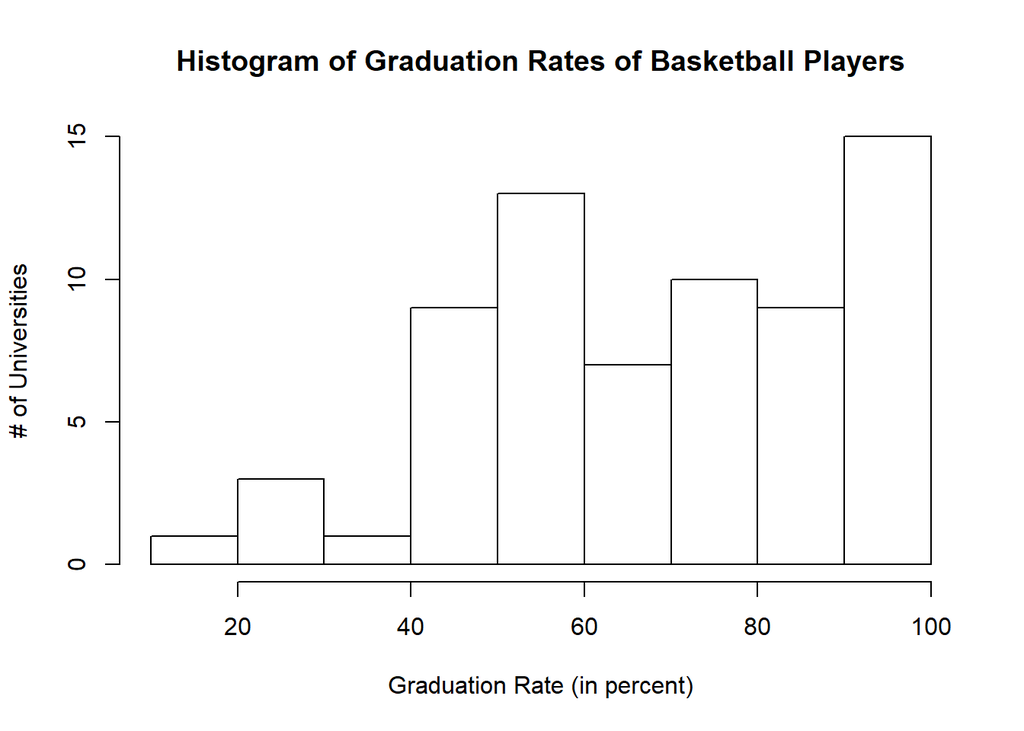

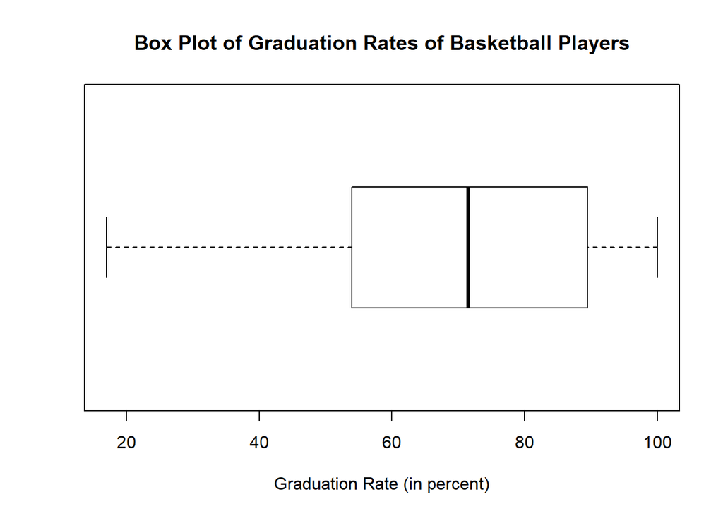

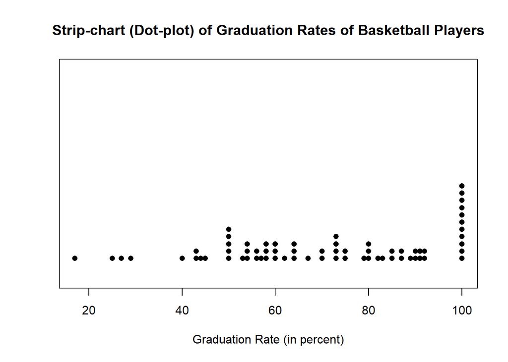

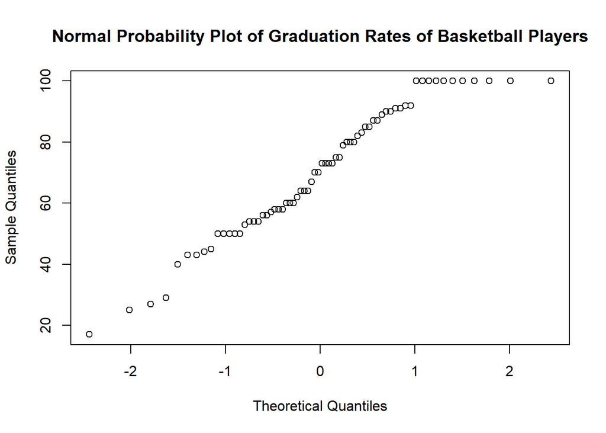

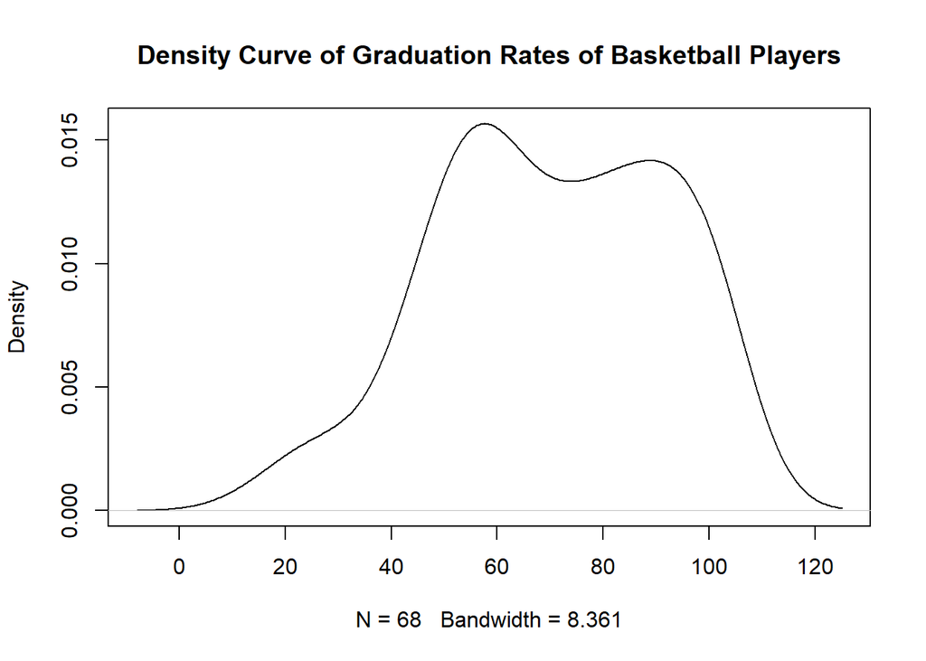

### Important Statistics

#### Summary

```
##    Min. 1st Qu.  Median    Mean 3rd Qu.    Max.
##   17.00   54.00   71.50   70.10   89.25  100.00
```

#### Standard Deviation

```
## [1] 21.60441
```

#### Interquartile Range

```
## [1] 35.25
```

### Statistical Analysis

Lets start this data analysis by describing the shape of the distribution. Looking at the graphs, we can see that many of the values lie to the left of the peak. Additionally, the mean is lower than the median, which would support a claim that the distribution is left-skewed. The difference between these two measures of center is awfully small, however, so I would classify this distribution as being “roughly” left-skewed.

Because of the skewed-ness of the distribution, we will use median as a measure of center. In this case, the median is 71.50%.

In terms of outliers, a quick glance at some of the graphs tells us there may be a few on the low side, particularly the universities that have a graduation rate for basketball players less than 40%. However, just by looking at the boxplot we can see that there are actually none.

Additionally, we will determine a measure of spread. Since we used median for the center, we will use the interquartile range (IQR) for the spread. The value of this is 35.25%, which tells us that 50% of universities have a graduation rate for basketball players that falls within 35.25 percentage points. To be more specific, 50% of universities have a graduation rate for basketball players that falls between 54% and 89.25%.

Just by going off of the skewed-ness of the graphs, we can say that the distribution is not normal. For even more evidence of this, we can look at the normal probability plot. In a normal distribution, the points in this plot should fall in a roughly straight line. However, we can see that there are very strong and systematic deviations from a linear pattern, particularly at the top and bottom. Also, the density curve is very uneven, with more of a tail on the left side and two humps in the middle, further supporting the fact that this distribution is not normal.

## All Athletes’ Graduation Rates

### Graphs

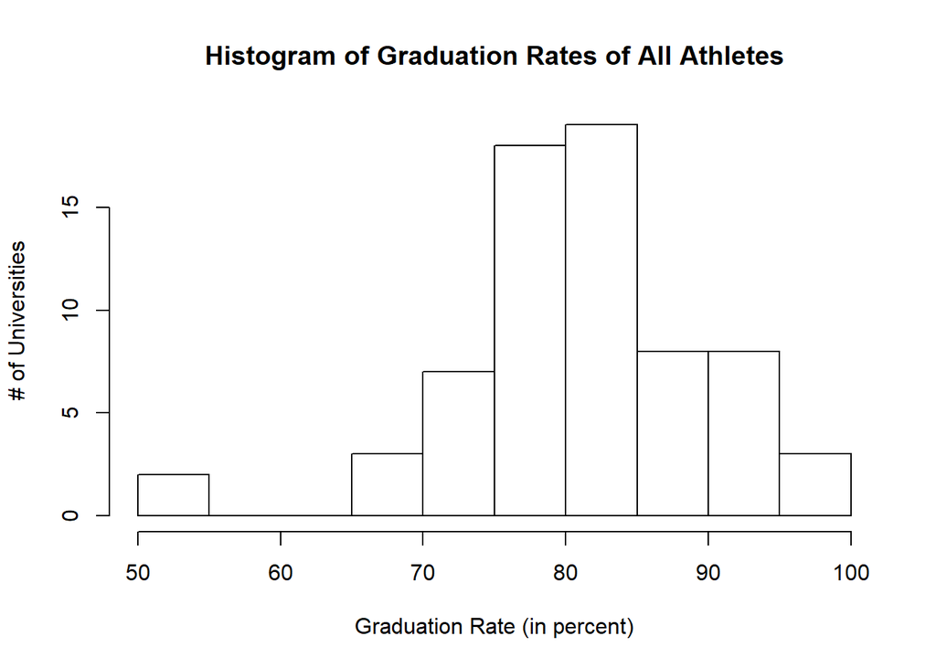

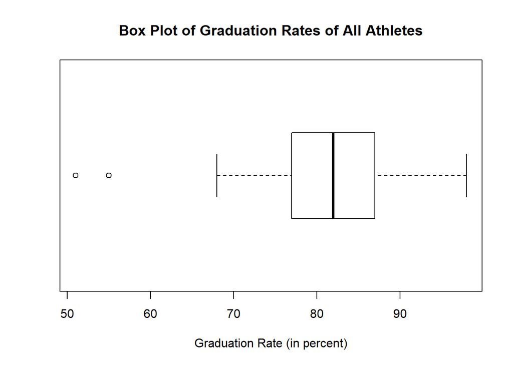

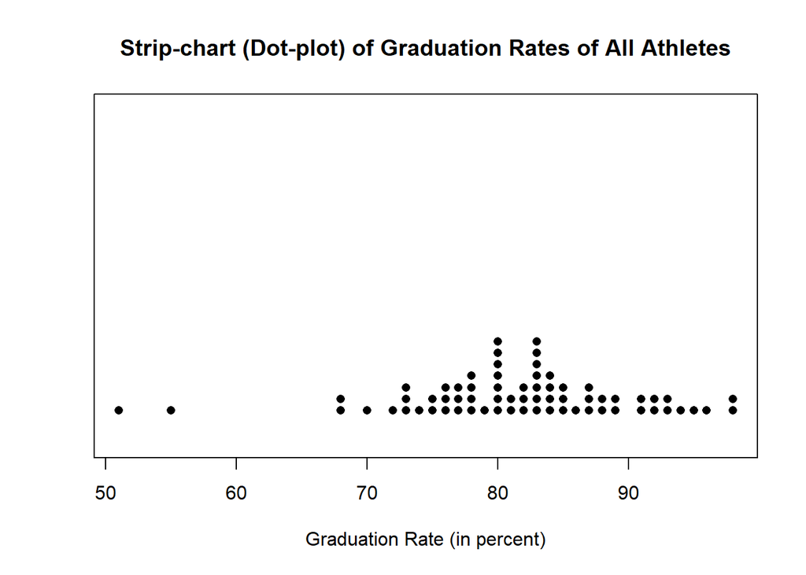

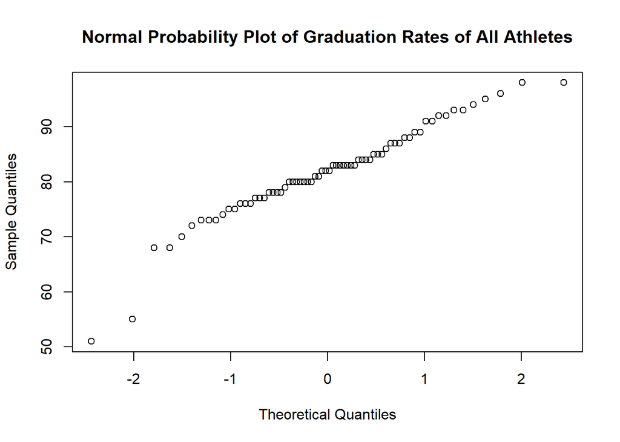

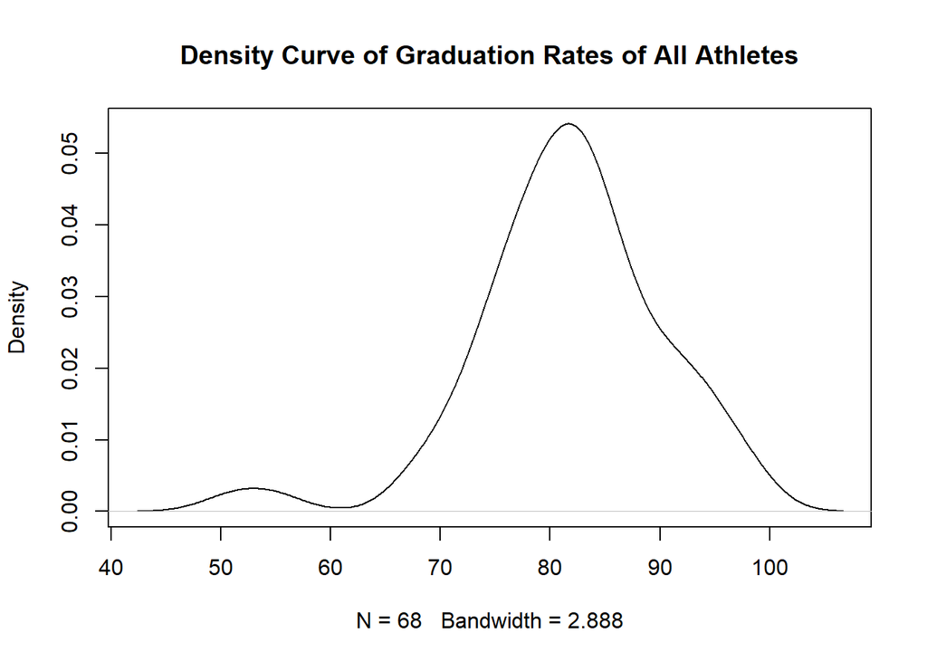

### Important Statistics

#### Summary

```
##    Min. 1st Qu.  Median    Mean 3rd Qu.    Max.
##   51.00   77.00   82.00   81.63   87.00   98.00
```

#### Standard Deviation

```
## [1] 8.590005
```

#### Interquartile Range

```
## [1] 10
```

### Statistical Analysis

Just like for the other data set, we will start this analysis with shape. This distribution seems to be fairly symmetrical, aside from a few potential outliers.

Speaking of outliers, we can see that there are two on the low side of the data set. These outliers are the universities with graduation rates for all athletes at 55% and 51%.

In this distribution, we will use mean to measure the center. In this case, it is 81.63%. In other words, the average university has a graduation rate for all athletes that is 81.63%.

Because of the symmetrical nature of the distribution and the use of mean for measure of center, we will use standard deviation to measure spread. In this distribution, it is 8.59%. In other words, most universities have a graduation rate for all athletes that falls within 8.59 percentile points of the mean, which is 81.63%.

We already know that this distribution is symmetrical, often being indicative of normality. Looking at the normal probability plot only further confirms this. Most points call in a clearly identifiable line, with only the outliers falling out of it. Also, the density curve appears to be fairly even, only being influence on the left side by the outliers yet again. Based on these observations, we can say that this distribution is fairly normal.

## Comparison

To start off this comparison, we can look at the clear differences, the first being the shape of the distribution. The graduation rates of basketball players is roughly left-skewed, while for the graduation rates of all athletes it is roughly symmetrical.

Additionally, the distribution of the graduation rates of all athletes has two low outliers, while for the graduation rates of basketball players there are none.

The measures of center also differ. For the graduation rates of basketball players we used median, due to the skewed-ness of the distribution. However, for the graduation rates of all athletes we used mean. Also, the center of the former distribution is much lower than the center of the latter, the difference being 10.13 percentile points.

These differences extend to the measure of spread, the distribution of the graduation rates of basketball players using IQR while the distribtution of graduation rates of all atheletes uses standard deviation. Although we cannot directly compare these two values, we can determine that since the spead of the latter distribution (8.59%) is significantly lower than the spread of the former (35.25%), values tend to lie closer together in the distribtuion of graduation rates of all athletes, as opposed to the other distribution.

Finally, they differ in normality, the distribution of graduation rates of basketball players not being normal while the distribution of graduation rates of all athletes is roughly normal.

In conclusion, through an analysis of various graphs and statistics, we can say that the graduation rates of basketball players tend to be lower, but more varied than those for all athletes.

AP Statistics Project

All rights reserved, 2019.